# Philippines Modeling Document

#### Prepared by Reduce.Reuse.Grow.Inc

[figure not shown]

## Abstract

- 1. System Overview
  - 1.1 System Goals
- 2. Data Specifications
  - 2.1 Collection Period
  - 2.2 Coordinate Systems
  - 2.3 Technology Stack
  - 2.4 Workbook Reproduction
- 3. Carbon Removals
  - 3.1 Biomass Training Dataset Collection
  - 3.2 Field Inventories
  - 3.3 Planting Methodology Distinctions
  - 3.4 Model Design
  - 3.5 Model Application
  - 3.6 Ex-Ante Estimates of Biomass Change
- 4. Project Emissions
  - 4.1 Fertilizer Use
  - 4.2 Leakage
- 5. Net Carbon Removals
  - 5.1 Project Instance Breakdown
  - 5.2 Gross Net Carbon Removals
  - 5.3 VCU's Per Year
- 6. Remote Sensing Performance Benchmark
  - 6.1 Modeling of SI at Biomass
  - 6.2 Baseline Biomass
- 7. Model Performance Discussion

## System Overview

RRG's modeling system is designed to estimate carbon removals and project emissions for Project ReGAIN. RRG will leverage field data, remote sensing, and statistical learning tools within Python, Google Earth Engine (GEE) and ArcGIS Pro. The workflow is structured arround Verra's [VM0047 Methodology](https://verra.org/wp-content/uploads/2023/09/VM0047_ARR_v1.0-1.pdf), which provides transparent, data-driven methodologies to track biomass change and net climate benefits over time.

#### System Goals

The primary goals of the system are to:

1. Quantify forest biomass and changes using field inventories and remote sensing data.
2. Estimate carbon removals and project emissions (e.g., from planting, fertilizer use and leakage).
3. Calculate net carbon benefits and project future VCUs.
4. Evaluate the performance of machine learning models.

## Data Specifications

#### Collection Period

The [World Bank Climate Change Portal](https://climateknowledgeportal.worldbank.org/country/philippines/climate-data-historical) provides precipitation data for Mindanao Island. Below is a climate graph of Mindanao.

[figure not shown]

Mindanao's main rainy season is from May to December, while the dry season is from January to April. RRG will select hyperspectral imagery for study from the dry season, in an effort to

- Reduce seasonal phenological variation
- Select months with the lowest cloud cover

SAR and LiDAR imagery are less suceptible to the above changes, however RRG will consistently select imagery from January to April for analysis. For training models, RRG uses a median value of all available data for the year.

#### Coordinate Systems

RRG will utilize two coordinate systems. One geographic coordinate system for web based applications, the other projected coordinate system for area analysis when area quantification must be as accurate as possible:

- Geographic Coordinate System: WGS 1984, EPSG: 4326
- Projected Coordinate System: WGS 1984 UTM Zone 51N, EPSG: 32651

#### Technology Stack

RRG will utilize industry standard technologies for data science, remote sensing and forest monitoring. The following technology stack will be used in development and implementation of RRG's modeling system.

**Remote Sensing**

- ArcGIS Pro
- Google Earth Engine [(GEE)](https://developers.google.com/earth-engine/datasets)

**Data Science**

- Python

**Reporting**

- [RRG's dMRV site](https://benparker9.github.io/RRG_dMRV/site/measure.html#wWrapperPhil)
- Jupyter lab Methodology Notebooks

#### Workbook Reproduction

This document provides a reproducible workflow using Python in a Jupyter Notebook environment. The document is rendered in HTML, so code cannot be run. Additionaly due to privacy issues, GEE maps do not render. However, many of the same maps are located at [RRG's dMRV site](https://benparker9.github.io/RRG_dMRV/).  
Auditors may request access to source files (.ipynb, .csv, .tif). Please contact ben@reducereusegrow.org.

```python
import ee
import folium
import geemap
import json
import geopandas as gpd
import numpy as np
import pandas as pd
import seaborn as sns
import matplotlib.pyplot as plt
import os
from IPython.display import Image
import scipy as stats
from lmfit import Model
import statsmodels.api as sm
import statsmodels.formula.api as smf
from sklearn.svm import SVR
from sklearn.preprocessing import StandardScaler
from sklearn.pipeline import make_pipeline
from sklearn.metrics import r2_score, mean_squared_error
from sklearn.model_selection import GridSearchCV
from sklearn.linear_model import Ridge
from sklearn.preprocessing import PolynomialFeatures
from sklearn.linear_model import LinearRegression
from sklearn.model_selection import train_test_split
import xgboost as xgb
pd.set_option('display.max_colwidth', None)
sns.set_theme(palette="Greens")
plt.rcParams.update({
    "font.family": "sans-serif",
    "font.sans-serif": ["Arial", "DejaVu Sans", "Verdana"],
    "figure.facecolor": "#121c16",
    "savefig.facecolor": "#121c16"
})
os.chdir('C:/Users/Ben/Documents/rrg_work/jupyter')
ee.Authenticate(auth_mode='localhost')
ee.Initialize(project='anacondagee')
```

```
*** Earth Engine *** Share your feedback by taking our Annual Developer Satisfaction Survey: https://google.qualtrics.com/jfe/form/SV_7TDKVSyKvBdmMqW?ref=4i2o6
```

## Carbon Removals

Per section 8.2.1 of the VM0047 methodology, carbon removals are estimated with the following equations:

[figure not shown]

Section 8.6 of the VM0047 methodology states the criteria to establish ex-ante estimates of carbon removals. Per this guidance, all other carbon pools (SOC, litter, etc.) can be assumed to be 0. The following equations describe how woody biomass removals should be quantified:

[figure not shown]

The ex-ante estimates for the average change in woody biomass will be quantified utilizing RRG's field inventory program.

#### Biomass Training Dataset Collection

RRG aims to train field inventory models based on validated LiDAR biomass training datasets provided by NASA and the UN. RRG aims to evaluate each dataset to select the most accurate representation of the Mindano region. RRG will utilize the training datasets to add biological caps to inventory models. Furthermore, RRG will train Stocking Index (SI) values on LiDAR biomass datasets to track changes in forest structure.

**Project Site Shapefiles**  
RRG has preloaded project shapefiles as cloud assests in GEE. Auditors may request access to assets.

```python
projectsites = ee.FeatureCollection('REQUEST')
pSitesGeom = projectsites.geometry()
mindanao = ee.FeatureCollection('REQUEST')
mindanaoGeom = mindanao.geometry()
om = ee.FeatureCollection('REQUEST')
omGeom = om.geometry()
SI_tests = ee.FeatureCollection('REQUEST')
SIGeom = SI_tests.geometry()
```

**[GEDI Raster ABV Biomass Density (2019-2024)](https://developers.google.com/earth-engine/datasets/catalog/LARSE_GEDI_GEDI04_A_002_MONTHLY#description)**

- Imagery is taken in sampling tracts and is not continuous.
- Imagery is subject to GEDI flightpaths. It is known remote regions are not covered. Data ranges in availability dependent on the year.
- There is little availabale data within the CADT of the OM or within the project zone.
- RRG will use this data set for current biomass estimates.

```python
def quality_mask(im):
    return im.updateMask(im.select('l4_quality_flag').eq(1)) \
             .updateMask(im.select('degrade_flag').eq(0)) \
             .updateMask(im.select('agbd').gt(0))
year = 2020
abgDF = ee.ImageCollection('LARSE/GEDI/GEDI04_A_002_MONTHLY')\
    .filterBounds(mindanaoGeom)\
    .filterDate(f'{year}-01-01', f'{year + 1}-04-01')
abgGEDI_geom = abgDF.geometry()
# Mosaic agbd band to a single image AND MULTIPLY BY CARBON FRACTION
abgraw = quality_mask(ee.Image(abgDF.mosaic())).select('agbd').multiply(0.47)
agbGEDI2020 = abgraw.clip(SIGeom)
```

**[Global Aboveground and Belowground Biomass Carbon Density Maps (2010)](https://developers.google.com/earth-engine/datasets/catalog/NASA_ORNL_biomass_carbon_density_v1#bands)**

- Meant to represent conditions in 2010
- Can select aboveground biomass, belowground biomass or both
- Continuous mapping of the entirety of Mindano Island

```python
agbDF2010 = ee.ImageCollection('NASA/ORNL/biomass_carbon_density/v1').filterBounds(projectsites)
agbNASA2010 = agbDF2010.select(['agb', 'bgb']).first().clip(mindanaoGeom)
```

**[WCMC Above and Below Ground Biomass Carbon Density (2010)](https://developers.google.com/earth-engine/datasets/catalog/WCMC_biomass_carbon_density_v1_0#description)**

- Meant to represent conditions from 1982-2010
- Both above and below ground biomass estimated as carbon tonnes per ha
- Continuous mapping of the entirety of Mindano Island

```python
agbUN = ee.Image('WCMC/biomass_carbon_density/v1_0/2010')
agbUN2010 = agbUN.select('carbon_tonnes_per_ha').clip(SIGeom)
```

**Visualize Results**

```python
#visualization parameters
psiteVis = {
    'fill': 'green'
}
agbVis = {
  'min': 0,
  'max': 500.0,
  'palette': ['d9f0a3', 'addd8e', '78c679', '41ab5d', '238443', '005a32']
}
gediVis = {
  'min': 0,
  'max': 500.0,
  'palette': ['red', 'yellow', 'green']
}
Map = geemap.Map(notebook_display=True)
Map.add_basemap('HYBRID')
Map.addLayer(agbUN2010, agbVis, 'Agb UN 2010')
Map.addLayer(agbNASA2010.select('agb'), agbVis, 'Agb NASA 2010')
Map.addLayer(agbGEDI2020, gediVis, 'Agb GEDI 2020')
Map.addLayer(projectsites, psiteVis, 'Project Sites')
Map.centerObject(projectsites, 10)
Map.add_inspector()
```

[figure not shown]

**Compare Results**

```python
bComps = pd.read_csv('./sheetsPhil/BiomassMindanaoComparison1.csv') #includes metadata
bComps.head()
bDF = bComps.rename(columns={
    bComps.columns[1]: 'Abv 2010 NASA Biomass',
    bComps.columns[2]: 'Abv 2020 Gedi Biomass',
    bComps.columns[3]: 'Below 2010 NASA Biomass',
    bComps.columns[4]: 'Abv/Below 2010 UN Biomass'
})
bDF['Abv/Below NASA Biomass 2010'] = bDF.iloc[:, 1] + bDF.iloc[:, 3]
bDF.head(1) #visualize raw data
```

|  | system:index | Abv 2010 NASA Biomass | Abv 2020 Gedi Biomass | Below 2010 NASA Biomass | Abv/Below 2010 UN Biomass | .geo | Abv/Below NASA Biomass 2010 |
| --- | --- | --- | --- | --- | --- | --- | --- |
| 0 | 0 | 52.025 | 55.008639 | 13.622 | 76.72 | {"geodesic":false,"type":"Point","coordinates":[125.17465771637706,9.003112973139665]} | 65.647 |

```python
bDF1 = bDF.iloc[:,[-1, -3, 2]]
bDF1.describe()
```

|  | Abv/Below NASA Biomass 2010 | Abv/Below 2010 UN Biomass | Abv 2020 Gedi Biomass |
| --- | --- | --- | --- |
| count | 22841.000000 | 22841.000000 | 22841.000000 |
| mean | 90.092944 | 109.764480 | 78.872601 |
| std | 28.109487 | 31.964666 | 65.716549 |
| min | 4.272000 | 5.708333 | 0.727901 |
| 25% | 71.975702 | 89.757774 | 34.825794 |
| 50% | 92.339801 | 115.232220 | 62.435415 |
| 75% | 109.480000 | 132.667790 | 103.258066 |
| max | 177.400000 | 214.502850 | 1704.456033 |

### Field Inventories

PEF has conducted initial field inventories of species to be planted. GEE datasets do not provide age data, however RRG can use the inventory data to forecast carbon removals throughout the project lifetime. RRG first converts DBH to mass (t) by utilizing allometric equations. RRG then models age and biomass to predict potential biomass of the site throughout the project lifetime. The following equation describes the model: $$ \text{Biomass (kg/tree)} = f(\text{Age}) $$

```python
field_df = pd.read_csv('./sheetsPhil/Yields.csv').iloc[:,0:3]
field_df.sample(5)
```

|  | Latin_Name | Age | DBH |
| --- | --- | --- | --- |
| 447 | Shorea sp. | 9.0 | 14.0 |
| 459 | Spondias pinnata | 30.0 | 30.0 |
| 311 | Nauclea orientalis | 5.0 | 3.5 |
| 402 | Pometia pinnata | 30.0 | 27.0 |
| 316 | Neonauclea formicarcia | 4.0 | 6.0 |

```python
field_df.describe()
```

|  | Age | DBH |
| --- | --- | --- |
| count | 537.000000 | 537.000000 |
| mean | 18.718622 | 24.728488 |
| std | 26.174703 | 28.100506 |
| min | 0.300000 | 1.000000 |
| 25% | 5.000000 | 7.957982 |
| 50% | 11.000000 | 17.000000 |
| 75% | 25.000000 | 30.000000 |
| max | 300.000000 | 360.000000 |

**Allometric Conversion**  
To convert DBH into aboveground weight (kg), RRG has conducted a thorough analysis of allometric equations for the Mindanao region. RRG chose the most conservative allometric equation provided by [Kenzo, et al.](https://www.jstage.jst.go.jp/article/tropics/advpub/0/advpub_MS22-09/_pdf/-char/ja)

```python
def allo(x):
    eq = (( 0.0829 * x ** 2.43 )*.001)
    return(eq)
inv_df = field_df.iloc[:,[1,2]]
inv_df['Biomass_t'] = allo(field_df['DBH']).round(decimals=2)
inv_df = inv_df.iloc[:,[0,2]]
inv_df.head(2)
```

|  | Age | Biomass_t |
| --- | --- | --- |
| 0 | 26.0 | 0.25 |
| 1 | 28.0 | 0.32 |

**Quick Look at Data Distributions**  
Quick look function to understand correlations, standard deviations and distributions.

```python
def ql(data):
    df = data.iloc[:, [0,1]]
    x = df.iloc[:,0]
    y = df.iloc[:,1]
    xName = df.columns[0]
    yName = df.columns[1]
    #Statistics
    df.corr()
    spearman_corr = x.corr(y, method='spearman')
    print('Spearman Correlation:', spearman_corr)
    # Calculate standard deviations
    std_x = df[xName].std()
    std_y = df[yName].std()
    # Create text for standard deviation
    textstrx = f'Standard Deviation of\n{xName}: {std_x:.2f}'
    textstry = f'Standard Deviation of\n{yName}: {std_y:.2f}'
    props = dict(boxstyle='round', facecolor='grey', alpha=0.5)
    # statistical graphs
    sns.set_theme()
    fig, axs = plt.subplots(2, 2, figsize=(10, 8))
    axs = axs.flatten()
    #Scatter plot distribution
    sns.scatterplot(x = f"{xName}", y = f"{yName}", data = df, alpha=0.5, color='purple', ax=axs[0])
    axs[0].set_title('Scatter Plot')
    axs[0].set_xlabel(f'{xName}')
    axs[0].set_ylabel(f'{yName}')
    #heatmap of correlations
    sns.heatmap(df.corr(), annot=True, cmap='coolwarm', ax=axs[1], cbar=True, cbar_kws={"label": "Correlation Coefficient"})
    axs[1].set_title('Correlation Heatmap')
    # hist plot
    sns.histplot(df[f"{xName}"], kde=True, color="darkgreen", ax=axs[2])
    axs[2].set_title(f'Distribution of {xName}')
    axs[2].set_xlabel(f'{xName}')
    axs[2].text(0.98, 0.95, textstrx, transform=axs[2].transAxes, fontsize=8,
        verticalalignment='top', bbox=props, horizontalalignment='right')
    sns.histplot(df[f"{yName}"], kde=True, color="darkgreen", ax=axs[3])
    axs[3].set_title(f'Distribution of {yName}')
    axs[3].text(0.98, 0.95, textstry, transform=axs[3].transAxes, fontsize=8,
        verticalalignment='top', bbox=props, horizontalalignment='right')
    axs[3].set_xlabel(f'{yName}')
    axs[3].set_xlim(0,5)
    fig.suptitle(f'Distribution of {xName} and {yName}')
    plt.tight_layout(rect=[0, 0.03, 1, 0.92], pad=1.0)
    plt.show()
```

```
Spearman Correlation: 0.9039671624720182
```

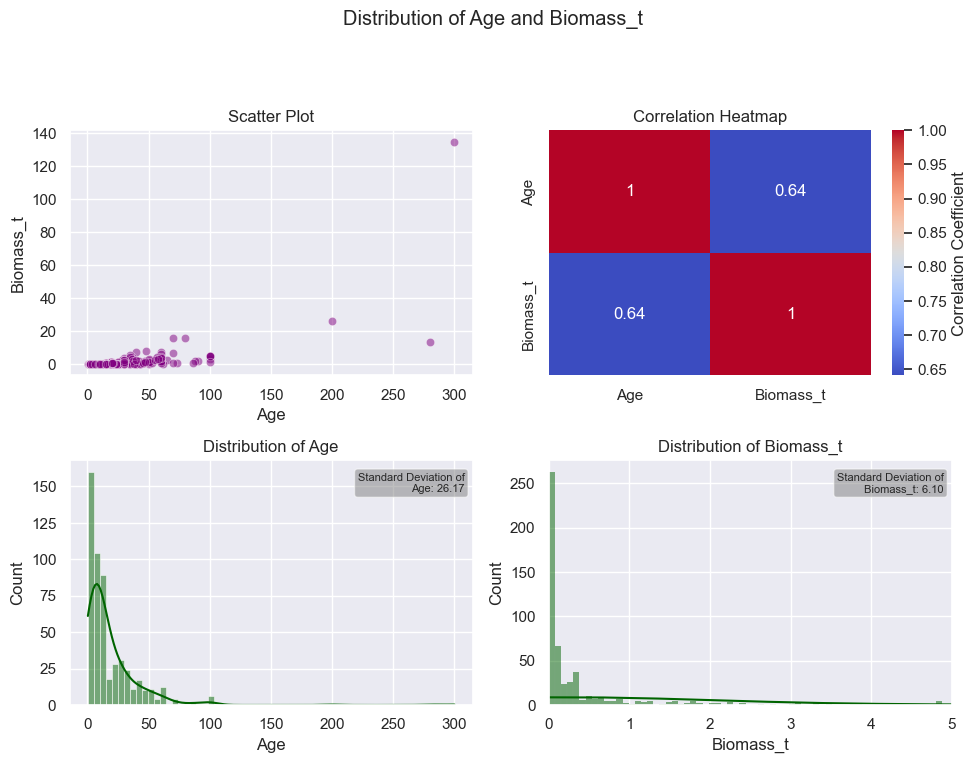

```
None
```

```python
print(ql(inv_df))
```

#### Planting Methodology Distinctions

**Planting Density**  
PEF is planting with four distinct density compositions through project instance 1 and 2. Below is the density composition and total estimated hectares planted for each methodology:

```python
method_df = pd.DataFrame({
    'Method' : ['Agroforestry', 'IAM', 'Miyawaki', 'Instance 2'],
    'Density' : [1125, 2500, 5000, 1009],
    'Ha Planted' : [1041, 478, 41.5, 3400]
})
```

Although PEF will plant with distinct density compositions, RRG will assume that the known biomass cielings apply to each methodology.

**Applying Known Biomass Cielings**  
Given the LiDAR biomass studies found in the training dataset analysis, the maximum biomass in Mindanao ranges from 170-220 tC/ha. Below RRG quantifies the maximum per tree biomass given the biological cieling.

```python
maxbiomass = 220
method_df['Maximum Single Tree Biomass'] = maxbiomass / method_df.iloc[:, 1]
method_df.head()
```

|  | Method | Density | Ha Planted | Maximum Single Tree Biomass |
| --- | --- | --- | --- | --- |
| 0 | Agroforestry | 1125 | 1041.0 | 0.195556 |
| 1 | IAM | 2500 | 478.0 | 0.088000 |
| 2 | Miyawaki | 5000 | 41.5 | 0.044000 |
| 3 | Instance 2 | 1009 | 3400.0 | 0.218038 |

#### Model Design

RRG has created a parametric regression modeling function to be used for each dataset. The function utilizes 2nd Polynomial, 3rd Polynomial, Logarithmic, Power and Chapman-Richard's equations to predict biomass given age. Included in the function are statistical metrics including R2, RMSE and MPE to track model quality.

```python
def model(data):
    df = data.copy()
    x = df.iloc[:, 0]
    y = df.iloc[:, 1]
    xName = df.columns[0]
    yName = df.columns[1]
    # PARAMETRIC MODELING
    #linear modeling/polynomial
    results = smf.wls(f'{yName} ~ {xName}', data=df, weights=df['weights']).fit()
    poly2 = smf.wls(f'{yName} ~ {xName} + I({xName}**2)', data=df, weights=df['weights']).fit()
    poly3 = smf.wls(f'{yName} ~ {xName} + I({xName}**2) + I({xName}**3)', data=df, weights=df['weights']).fit()
    #non linear with including log, power, exponential, chapman richards
    def power(x, a,b):
        return a * x**b
    powerModel = Model(power)
    pParams = powerModel.make_params(a=0.5, b=1)
    pParams['a'].set(min=0)
    pParams['b'].set(min=0)
    pResult = powerModel.fit(df[f'{yName}'], pParams, x =df[f'{xName}'], weights=df['weights'])
    def CR(x, a, b, c):
        return a * (1 - np.exp(-b * x))**c
    CRModel = Model(CR)
    CRParams = CRModel.make_params(a=(df[f'{yName}'].max()), b=0.03, c=2)
    CRParams['a'].set(min=0)
    CRParams['b'].set(min=0)
    CRParams['c'].set(min=0)
    CRResult = CRModel.fit(df[f'{yName}'].values, CRParams, x=df[f'{xName}'].values, nan_policy='omit', weights=df['weights'])
    def log(x, a, b):
        return a * np.log(x) + b
    logModel = Model(log)
    lParams = logModel.make_params(a=0.5, b=1)
    lResult = logModel.fit(df[f'{yName}'], lParams, x=df[f'{xName}'], nan_policy='omit', weights=df['weights'])

    # QUICK LOOK TO COMPARE MODEL OUTCOMES
    # Mean Percentage Error
    def mean_percentage_error(y_true, y_pred):
        y_true, y_pred = np.array(y_true), np.array(y_pred)
        nonzero_mask = y_true != 0
        if not np.any(nonzero_mask):
        # All y_true are zero, can't compute MPE
            return np.nan
        mpe = np.mean((y_true[nonzero_mask] - y_pred[nonzero_mask]) / y_true[nonzero_mask]) * 100
        return mpe
    def evaluate_model(name, y_true, y_pred, formula):
        return {
        'Model': name,
        'Formula': formula,
        'R²': r2_score(y_true, y_pred),
        'RMSE': np.sqrt(mean_squared_error(y_true, y_pred)),
        'MPE': mean_percentage_error(y_true, y_pred)
    }
    results_list = []
    y_pred_linear = results.predict(df)
    formula_linear = f"{yName} = {results.params['Intercept']:.3f} + {results.params[xName]:.3f} * {xName}"
    results_list.append(evaluate_model('Linear', df[yName], y_pred_linear, formula_linear))
    y_pred_poly2 = poly2.predict(df)
    formula_poly2 = (f"{yName} = {poly2.params['Intercept']:.3f} + "
                 f"{poly2.params[xName]:.3f} * {xName} + "
                 f"{poly2.params[f'I({xName} ** 2)']:.3f} * {xName}²")
    results_list.append(evaluate_model('Polynomial (2nd)', df[yName], y_pred_poly2, formula_poly2))
    y_pred_poly3 = poly3.predict(df)
    formula_poly3 = (f"{yName} = {poly3.params['Intercept']:.3f} + "
                 f"{poly3.params[xName]:.3f} * {xName} + "
                 f"{poly3.params[f'I({xName} ** 2)']:.3f} * {xName}² + "
                 f"{poly3.params[f'I({xName} ** 3)']:.3f} * {xName}³")
    results_list.append(evaluate_model('Polynomial (3rd)', df[yName], y_pred_poly3, formula_poly3))
    y_pred_log = lResult.eval(x=df[xName])
    aL = lResult.params['a'].value
    bL = lResult.params['b'].value
    formula_log = f"{yName} = {aL:.3f} * ln({xName}) + {bL:.3f}"
    results_list.append(evaluate_model('Logarithmic', df[yName], y_pred_log, formula_log))
    y_pred_power = pResult.eval(x=df[xName])
    aP = pResult.params['a'].value
    bP = pResult.params['b'].value
    formula_power = f"{yName} = {aP:.14f} * {xName} ^ {bP:.3f}"
    results_list.append(evaluate_model('Power', df[yName], y_pred_power, formula_power))
    y_pred_CR = CRResult.eval(x=df[xName])
    aCR = CRResult.params['a'].value
    bCR = CRResult.params['b'].value
    cCR = CRResult.params['c'].value
    formula_CR = f"{yName} = {aCR:.3f} * (1 - exp(-{bCR:.3f} * {xName})) ^ {cCR:.3f}"
    results_list.append(evaluate_model('Chapman-Richards', df[yName], y_pred_CR, formula_CR))
    metrics_df = pd.DataFrame(results_list)
    metrics_df = metrics_df.sort_values(by='R²', ascending=False).reset_index(drop=True)


    #GRAPH RESULTS
    # Create x values
    x_vals = np.linspace(1.3 * df[xName].min(), 1.3 * df[xName].max(), 200)
    # Scatter plots of original data
    fig, axs = plt.subplots(1, 2, figsize=(12, 6))
    axs[0].scatter(df[xName], df[yName], label='Inventory Data', color='lightblue', alpha=0.6, s=20)
    axs[1].scatter(df[xName], df[yName], label='Inventory Data', color='lightblue', alpha=0.6, s=15)
    # Linear
    y_vals_linear = results.params['Intercept'] + results.params[xName] * x_vals
    axs[0].plot(x_vals, y_vals_linear, label='Linear', color='blue', linestyle='-')
    axs[1].plot(x_vals, y_vals_linear, label='Linear', color='blue', linestyle='-')
    # Polynomial 2nd degree
    y_vals_poly2 = (poly2.params['Intercept']
                + poly2.params[xName] * x_vals
                + poly2.params[f'I({xName} ** 2)'] * x_vals**2)
    axs[0].plot(x_vals, y_vals_poly2, label='Polynomial (2nd)', color='green', linestyle='--')
    axs[1].plot(x_vals, y_vals_poly2, label='Polynomial (2nd)', color='green', linestyle='--')
    # Polynomial 3rd degree
    y_vals_poly3 = (
    poly3.params['Intercept']
    + poly3.params[xName] * x_vals
    + poly3.params[f'I({xName} ** 2)'] * x_vals**2
    + poly3.params[f'I({xName} ** 3)'] * x_vals**3
    )
    axs[0].plot(x_vals, y_vals_poly3, label='Polynomial (3rd)', color='darkgreen', linestyle=':')
    axs[1].plot(x_vals, y_vals_poly3, label='Polynomial (3rd)', color='darkgreen', linestyle=':')
    # Power
    aP = pResult.params['a'].value
    bP = pResult.params['b'].value
    y_vals_power = aP * x_vals**bP
    axs[0].plot(x_vals, y_vals_power, label='Power', color='purple', linestyle='-.', linewidth = 2)
    axs[1].plot(x_vals, y_vals_power, label='Power', color='purple', linestyle='-.', linewidth = 2)
    # Logarithmic (only valid for x_vals > 0)
    x_vals_log = x_vals[x_vals > 0]
    y_vals_log = lResult.params['a'].value * np.log(x_vals_log) + lResult.params['b'].value
    axs[0].plot(x_vals_log, y_vals_log, label='Logarithmic', color='orange', linestyle='--')
    axs[1].plot(x_vals_log, y_vals_log, label='Logarithmic', color='orange', linestyle='--')
    # Chapman-Richards
    aCR = CRResult.params['a'].value
    bCR = CRResult.params['b'].value
    cCR = CRResult.params['c'].value
    y_vals_CR = aCR * (1 - np.exp(-bCR * x_vals))**cCR
    axs[0].plot(x_vals, y_vals_CR, label='Chapman-Richards', color='brown', linestyle='-.')
    axs[1].plot(x_vals, y_vals_CR, label='Chapman-Richards', color='brown', linestyle='-.')
    # Final plot formatting
    axs[0].set_ylim(-5, (1.2*df[xName].max()))
    axs[0].set_xlim(0,(1.2*df[xName].max()))
    axs[1].set_ylim(-.01, .4)
    axs[1].set_xlim(0,50)
    for ax in axs.flat:
        ax.set(xlabel='Age', ylabel='Biomass per Tree (tC)')
    plt.suptitle('Predicting Biomass per Tree Given Inventory Data')
    plt.legend()
    plt.show()
    return metrics_df
```

```python
# agroforestry/project instance 2
miya = inv_df.copy()
miya['weights'] = np.where(miya['Biomass_t'] < 0.06, 10000, 1)
agro = inv_df.copy()
agro['weights'] = np.where(agro['Biomass_t'] < 0.3, 10000, 1)
iam = inv_df.copy()
iam['weights'] = np.where(iam['Biomass_t'] < 0.12, 10000, 1)
```

#### Model Application

##### Miyawaki

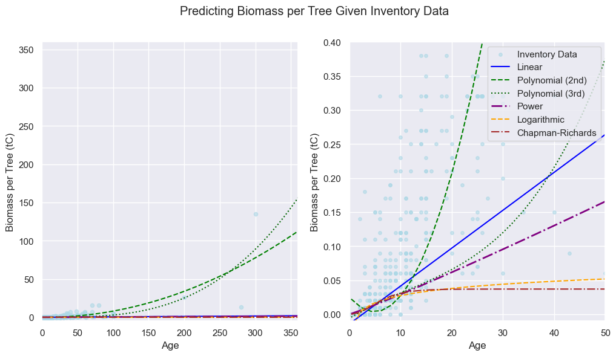

|  | Model | Formula | R² | RMSE | MPE |
| --- | --- | --- | --- | --- | --- |
| 0 | Polynomial (3rd) | Biomass_t = -0.006 + 0.005 * Age + -0.000 * Age² + 0.000 * Age³ | 0.676008 | 3.467197 | 43.680929 |
| 1 | Polynomial (2nd) | Biomass_t = 0.026 + -0.009 * Age + 0.001 * Age² | 0.648728 | 3.610212 | -6.765982 |
| 2 | Linear | Biomass_t = -0.014 + 0.006 * Age | 0.014843 | 6.045938 | 41.138948 |
| 3 | Power | Biomass_t = 0.00243091282526 * Age ^ 1.079 | 0.004115 | 6.078770 | 53.703080 |
| 4 | Logarithmic | Biomass_t = 0.015 * ln(Age) + -0.008 | -0.016343 | 6.140889 | 58.716834 |
| 5 | Chapman-Richards | Biomass_t = 0.037 * (1 - exp(-0.298 * Age)) ^ 3.521 | -0.017416 | 6.144129 | 59.471420 |

```python
metrics_df = model(miya)
metrics_df.head(6)
```

**Model Selection**  
RRG has chosen the Chapman-Richards for the Miyawaki composition. Despite the low R2, high MPE and high RMSE, RRG will use the Chapman-Richards curve sigmoidal shape to forecast potential tree growth. RRG understands model tests indicate low model performance. Because RRG heavily weighed the lower portion of the dataset, all statistical tests are expected to be negatively impacted.  
Moving into the future, RRG and PEF will collect additional inventory data to strengthen model results.

```python
def miya_func(Age):
    biomass =  0.037 * (1 - np.exp(-0.298 * Age)) ** 3.521
    return(biomass)
```

##### IAM

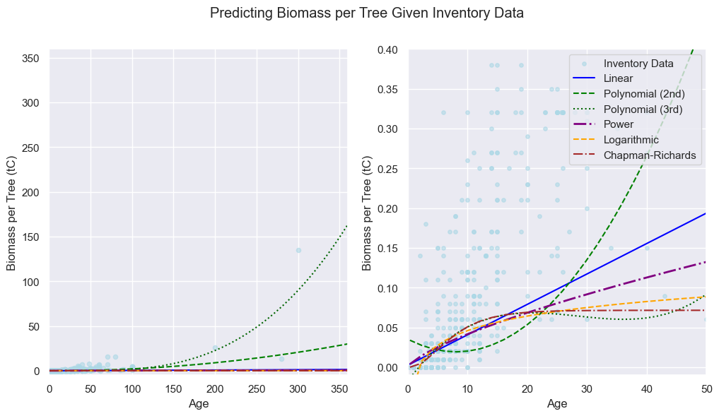

|  | Model | Formula | R² | RMSE | MPE |
| --- | --- | --- | --- | --- | --- |
| 0 | Polynomial (3rd) | Biomass_t = -0.017 + 0.010 * Age + -0.000 * Age² + 0.000 * Age³ | 0.675078 | 3.472165 | 29.613097 |
| 1 | Polynomial (2nd) | Biomass_t = 0.035 + -0.004 * Age + 0.000 * Age² | 0.280752 | 5.165951 | 37.122196 |
| 2 | Linear | Biomass_t = 0.002 + 0.004 * Age | 0.004926 | 6.076293 | 34.366180 |
| 3 | Power | Biomass_t = 0.00791107409690 * Age ^ 0.720 | -0.007574 | 6.114338 | 32.575836 |
| 4 | Logarithmic | Biomass_t = 0.026 * ln(Age) + -0.015 | -0.014452 | 6.135172 | 31.744187 |
| 5 | Chapman-Richards | Biomass_t = 0.072 * (1 - exp(-0.219 * Age)) ^ 2.889 | -0.015939 | 6.139667 | 34.560337 |

```python
metrics_df = model(iam)
metrics_df.head(6)
```

**Model Selection**  
RRG has chosen the Chapman-Richards for the IAM composition. Despite the low R2, high MPE and high RMSE, RRG will use the Chapman-Richards curve sigmoidal shape to forecast potential tree growth. RRG understands model tests indicate low model performance. Because RRG heavily weighed the lower portion of the dataset, all statistical tests are expected to be negatively impacted.  
Moving into the future, RRG and PEF will collect additional inventory data to strengthen model results.

```python
def iam_func(Age):
    biomass =  0.072 * (1 - np.exp(-0.219 * Age)) ** 2.889
    return(biomass)
```

##### Agroforestry

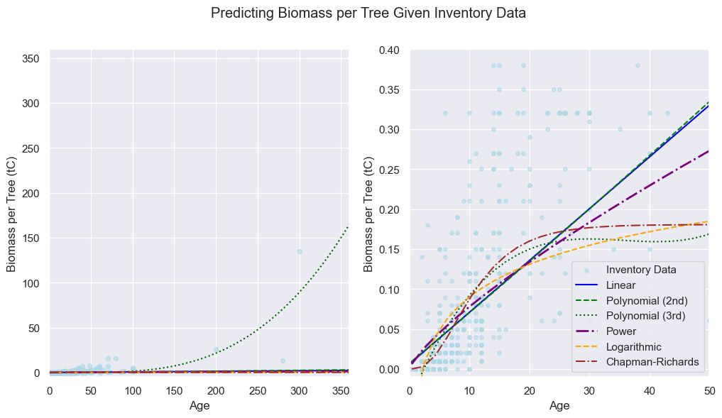

|  | Model | Formula | R² | RMSE | MPE |
| --- | --- | --- | --- | --- | --- |
| 0 | Polynomial (3rd) | Biomass_t = -0.040 + 0.018 * Age + -0.001 * Age² + 0.000 * Age³ | 0.677918 | 3.456957 | -19.480530 |
| 1 | Polynomial (2nd) | Biomass_t = 0.007 + 0.006 * Age + 0.000 * Age² | 0.027830 | 6.005957 | -15.284677 |
| 2 | Linear | Biomass_t = 0.006 + 0.006 * Age | 0.021122 | 6.026640 | -15.197935 |
| 3 | Power | Biomass_t = 0.01293492330153 * Age ^ 0.779 | 0.006083 | 6.072760 | -25.280921 |
| 4 | Logarithmic | Biomass_t = 0.059 * ln(Age) + -0.046 | -0.009516 | 6.120229 | -26.318381 |
| 5 | Chapman-Richards | Biomass_t = 0.181 * (1 - exp(-0.171 * Age)) ^ 3.629 | -0.011498 | 6.126234 | -4.949477 |

```python
metrics_df = model(agro)
metrics_df.head(6)
```

**Model Selection**  
RRG has chosen the Chapman-Richards for the agroforestry composition. Despite the low R2, high MPE and high RMSE, RRG will use the Chapman-Richards curve sigmoidal shape to forecast potential tree growth. RRG understands model tests indicate low model performance. Because RRG heavily weighed the lower portion of the dataset, all statistical tests are expected to be negatively impacted.  
Moving into the future, RRG and PEF will collect additional inventory data to strengthen model results.

```python
def agro_func(Age):
    biomass =  0.181 * (1 - np.exp(-0.171 * Age)) ** 3.629
    return(biomass)
```

#### Ex-Ante Estimates of Biomass Change

**Biomass Scaling**  
The modeling process above quantifies the estimated average single tree biomass. To quantify the per hectare biomass, these values must be scaled by density (trees/hectare).

```python
method_df.head() #to see below .iloc
```

|  | Method | Density | Ha Planted | Maximum Single Tree Biomass |
| --- | --- | --- | --- | --- |
| 0 | Agroforestry | 1125 | 1041.0 | 0.195556 |
| 1 | IAM | 2500 | 478.0 | 0.088000 |
| 2 | Miyawaki | 5000 | 41.5 | 0.044000 |
| 3 | Instance 2 | 1009 | 3400.0 | 0.218038 |

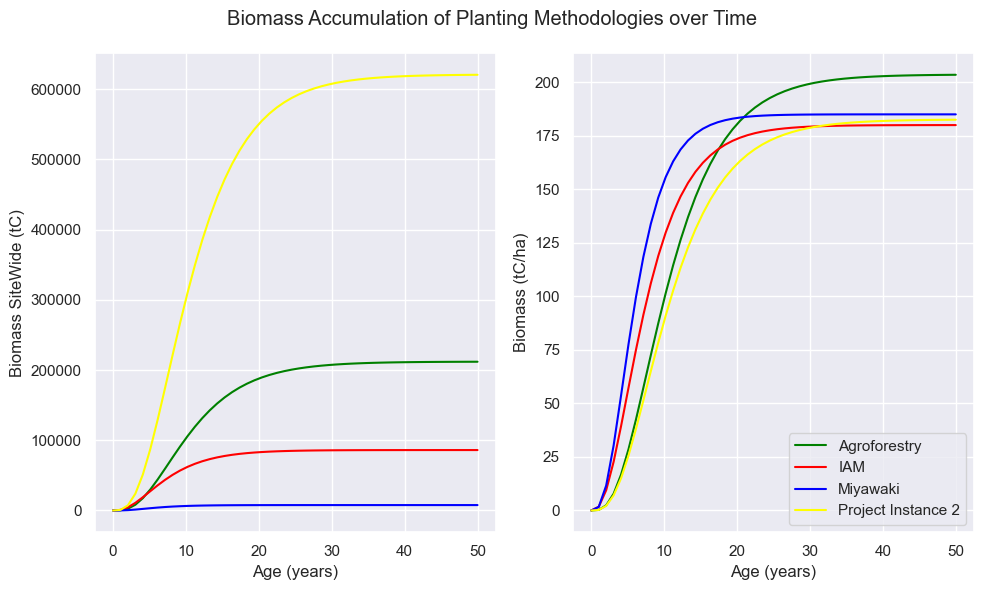

```python
x1 = np.linspace(0,50, 50)
agroHa = agro_func(x1) * method_df.iloc[0,1]
expHa = agro_func(x1) * method_df.iloc[3,1]
iamHa = (iam_func(x1) * method_df.iloc[1,1])
miyaHa = (miya_func(x1) * method_df.iloc[2,1])
agroSite = agroHa * method_df.iloc[0,2]
expSite = expHa * method_df.iloc[3,2]
iamSite = (iamHa * method_df.iloc[1,2])
miyaSite = (miyaHa * method_df.iloc[2,2])
fig, axs = plt.subplots(1, 2, figsize=(10, 6))
axs[1].plot(x1, agroHa, label='Agroforestry', color='green')
axs[1].plot(x1, iamHa, label='IAM', color='red')
axs[1].plot(x1, miyaHa, label='Miyawaki', color='blue')
axs[1].plot(x1, expHa, label='Project Instance 2', color='yellow')
axs[0].plot(x1, agroSite, label='Agroforestry', color='green')
axs[0].plot(x1, iamSite, label='IAM', color='red')
axs[0].plot(x1, miyaSite, label='Miyawaki', color='blue')
axs[0].plot(x1, expSite, label='Project Instance 2', color='yellow')
for ax in axs.flat:
    ax.set(xlabel='Age (years)')
axs[0].set_ylabel('Biomass SiteWide (tC)')
axs[1].set_ylabel('Biomass (tC/ha)')
plt.suptitle('Biomass Accumulation of Planting Methodologies over Time')
plt.grid(True)
plt.legend()
plt.tight_layout()
plt.show()
```

**Estimated Carbon Removals per Project Instance**

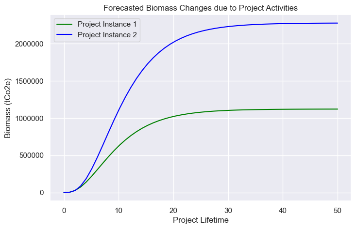

```python
pInstance1 = (agroSite + iamSite + miyaSite) * (44/12)
pInstance2 = expSite * (44/12)
plt.figure(figsize=(8,5))
plt.plot(x1, pInstance1, label='Project Instance 1', color = 'green')
plt.plot(x1, pInstance2, label='Project Instance 2', color = 'blue')
plt.title('Forecasted Biomass Changes due to Project Activities')
plt.xlabel('Project Lifetime')
plt.ylabel('Biomass (tCo2e)')
plt.ticklabel_format(style='plain', axis='y')
plt.legend()
plt.show()
```

#### Quantifying Uncertainty with Quartile-Based Performance Scenarios

RRG understands the complexity of forest restoration and the need for a sliding scale of performance biomass outcomes. RRG trained the models with the understanding that project activities cannot outpreform existing old-growth forests in biomass growth. In conjunction, RRG needs to estimate worse case scenarios where poor site conditions (competing vegetation, dry) or catastrophic risk events influence growth. So, RRG has prepared quartile based scaling scenarios for ex-ante predictions of carbon removals:

- Low Performing Models (25%, delta tC/ha = 50)
- Mid Performing Models (50-75%, delta tC/ha = 100-150)
- High Performing Models (100%, delta tC/ha = 200)

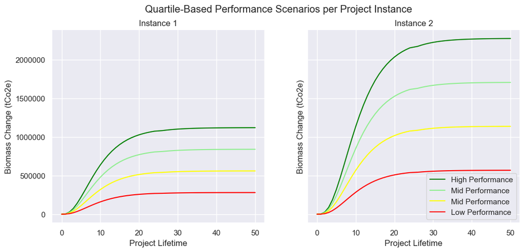

```python
netRemovals_p1 = pd.DataFrame({
    'Year' : np.round(x1),
    'High_Co2e': pInstance1,
    'Mid1_Co2e': pInstance1 * 0.75,
    'Mid2_Co2e': pInstance1 * 0.5,
    'Low_Co2e': pInstance1 * 0.25
})
netRemovals_p2 = pd.DataFrame({
    'Year' : np.round(x1),
    'High_Co2e': pInstance2,
    'Mid1_Co2e': pInstance2 * 0.75,
    'Mid2_Co2e': pInstance2 * 0.5,
    'Low_Co2e': pInstance2 * 0.25
})
fig, axs = plt.subplots(1, 2, figsize=(12, 5), sharey=True)
axs[0].plot(netRemovals_p1.iloc[:,0], netRemovals_p1.iloc[:,1], label='High Performance', color = 'green')
axs[0].plot(netRemovals_p1.iloc[:,0], netRemovals_p1.iloc[:,2], label='Mid Performance', color = 'lightgreen')
axs[0].plot(netRemovals_p1.iloc[:,0], netRemovals_p1.iloc[:,3], label='Mid Performance', color = 'yellow')
axs[0].plot(netRemovals_p1.iloc[:,0], netRemovals_p1.iloc[:,4], label='Low Performance', color = 'red')
axs[0].set_title('Instance 1')
axs[1].plot(netRemovals_p2.iloc[:,0], netRemovals_p2.iloc[:,1], label='High Performance', color = 'green')
axs[1].plot(netRemovals_p2.iloc[:,0], netRemovals_p2.iloc[:,2], label='Mid Performance', color = 'lightgreen')
axs[1].plot(netRemovals_p2.iloc[:,0], netRemovals_p2.iloc[:,3], label='Mid Performance', color = 'yellow')
axs[1].plot(netRemovals_p2.iloc[:,0], netRemovals_p2.iloc[:,4], label='Low Performance', color = 'red')
axs[1].set_title('Instance 2')
for ax in axs.flat:
    ax.set(xlabel='Project Lifetime', ylabel='Biomass Change (tCo2e)')
plt.suptitle('Quartile-Based Performance Scenarios per Project Instance')
plt.ticklabel_format(style='plain', axis='y')
plt.legend()
plt.show()
```

## Project Emissions

Per section 8.2.2 of the VM0047 methodology, project emissions result from biomass burning and fertilizer use. PEF will not burn any land, so biomass burning is assumed to be 0. However, PEF will be utilizing small amounts of fertilizer. The below equation summarizes project emissions:

[figure not shown]

#### Fertilizer Use

PEF will be utilizing four distinct fertilizers to prep sites and ensure strong saplings. All fertilizers will be made by PEF from natural waste found throughout the nursery areas. It is expected that PEF will utilize these fertilizers from years 1-3 for each project instance. However, PEF will monitor and track their fertilizer use.  
[Attached here](https://docs.google.com/document/d/1Z5JtSc4RT0DZXd64uHlfG_oOwWxp9t6h8AvUT48b8ZU/edit?tab=t.0) is the documentation for how RRG quantified fertilizer use including each fertilizer description.

RRG estimates that per year, project instance 1 will emit **56,577.48 tCo2** from fertilizer use. While project instance 2 will emit **73,411 tCo2e** per year. In total, RRG estimates that project activities will emit **389,964 tCo2** from fertilizer use.

```python
fertilizer_emissions1 = [56577.48, 56577.48, 56577.48]
fertilizer_emissions2 = [73411, 73411, 73411]
# Fill the rest with 0
remaining_years1 = len(netRemovals_p1) - len(fertilizer_emissions1)
remaining_years2 = len(netRemovals_p2) - len(fertilizer_emissions2)
fertilizer_column1 = fertilizer_emissions1 + [0] * remaining_years1
fertilizer_column2 = fertilizer_emissions2 + [0] * remaining_years2
# Add to DataFrame
netRemovals_p1['Fertilizer Emissions (tCo2)'] = fertilizer_column1
netRemovals_p2['Fertilizer Emissions (tCo2)'] = fertilizer_column2
netRemovals_p2.head()
```

|  | Year | High_Co2e | Mid1_Co2e | Mid2_Co2e | Low_Co2e | Fertilizer Emissions (tCo2) |
| --- | --- | --- | --- | --- | --- | --- |
| 0 | 0.0 | 0.000000 | 0.000000 | 0.000000 | 0.000000 | 73411 |
| 1 | 1.0 | 2952.566651 | 2214.424988 | 1476.283325 | 738.141663 | 73411 |
| 2 | 2.0 | 26985.187929 | 20238.890946 | 13492.593964 | 6746.296982 | 73411 |
| 3 | 3.0 | 87623.802239 | 65717.851680 | 43811.901120 | 21905.950560 | 0 |
| 4 | 4.0 | 187253.478847 | 140440.109135 | 93626.739423 | 46813.369712 | 0 |

#### Leakage

Mindanao Island has available data regarding historical grower records and illegal logging rates. However, there is no data available for the Obu-Manuvu people. RRG can see from remote sensing that farms throughout the project zone are quite small and are believed to be subsistence farms.  
Moving into the future, RRG and PEF will complete the FPIC process and hold local farmer interviews to determine foregone production within the project area. Project activities will not displace any farms within the project area. PEF aims to mitigate leakage into the surrounding region by employing these farmers and providing them with an alternate, sustainable livelihood.  
Until the FPIC process occurs, RRG has decided to implement the default leakage deductions set out in the Verra Standard, v4.7. These deductions are taken from the gross Co2e removals and are 15% from activity shifting leakage and 10% from market shifting leakage.  
RRG will ultimately use the VM0054 ARR Leakage module to calculate leakage. This module first estimates leakage by calculating production (based on grower records), an anticipated amount of new land brought into production and the determination of the change in carbon stock due to this land change. Cumulatively, the following equation describes how RRG will quantify leakage.

[figure not shown]

For ex-ante estimations, leakage must be quantified in tCo2. To do this with the default 25% rate, RRG takes 25% of total Co2e removals from each performance scenario.

```python
def leak(mass):
    metric = mass * 0.25
    return(metric)
```

## Net Carbon Removals

Per section 8.5 of the VM0047 methodology, net carbon removals are quantified as follows:

[figure not shown]

**Uncertainty**  
Currently, RRG is using the default uncertainty rate of 10%. Moving into the future, RRG will quantify uncertainty utilizing equation 27 of the VM0047 methodology.

```python
unc = .1
```

**Performance Benchmark**  
Because project activities have just begun, RRG is not currently able to quantify the performance benchmark metric. For ex-ante net carbon removals, RRG has chosen a value of 0. In the immediate future, RRG will complete the performance benchmark analysis.

```python
PB = 0
```

#### Project Instance Breakdown

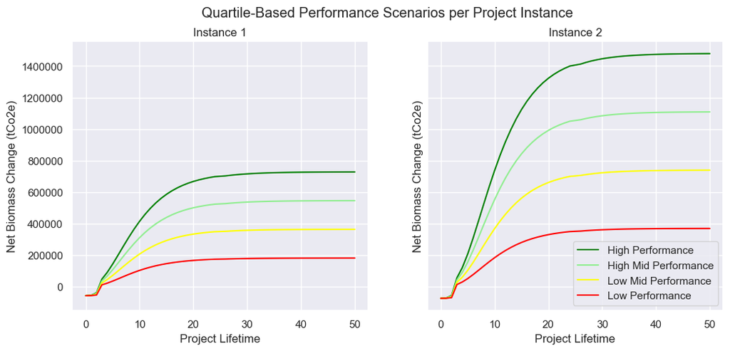

```python
# quantify net removals
#p1 calc
netRemovals_p1['Net Co2e Removals High'] = ((netRemovals_p1.iloc[:,1] * (1- PB) * (1-unc))\
                                     - leak(netRemovals_p1.iloc[:,1])) - netRemovals_p1.iloc[:,5]
netRemovals_p1['Net Co2e Removals Upper Mid'] = ((netRemovals_p1.iloc[:,2] * (1- PB) * (1-unc))\
                                     - leak(netRemovals_p1.iloc[:,2])) - netRemovals_p1.iloc[:,5]
netRemovals_p1['Net Co2e Removals Lower Mid'] = ((netRemovals_p1.iloc[:,3] * (1- PB) * (1-unc))\
                                     - leak(netRemovals_p1.iloc[:,3])) - netRemovals_p1.iloc[:,5]
netRemovals_p1['Net Co2e Removals Low'] = ((netRemovals_p1.iloc[:,4] * (1- PB) * (1-unc))\
                                     - leak(netRemovals_p1.iloc[:,4])) - netRemovals_p1.iloc[:,5]
# p2 calc
netRemovals_p2['Net Co2e Removals High'] = ((netRemovals_p2.iloc[:,1] * (1- PB) * (1-unc))\
                                     - leak(netRemovals_p2.iloc[:,1])) - netRemovals_p2.iloc[:,5]
netRemovals_p2['Net Co2e Removals Upper Mid'] = ((netRemovals_p2.iloc[:,2] * (1- PB) * (1-unc))\
                                     - leak(netRemovals_p2.iloc[:,2])) - netRemovals_p2.iloc[:,5]
netRemovals_p2['Net Co2e Removals Lower Mid'] = ((netRemovals_p2.iloc[:,3] * (1- PB) * (1-unc))\
                                     - leak(netRemovals_p2.iloc[:,3])) - netRemovals_p2.iloc[:,5]
netRemovals_p2['Net Co2e Removals Low'] = ((netRemovals_p2.iloc[:,4] * (1- PB) * (1-unc))\
                                     - leak(netRemovals_p2.iloc[:,4])) - netRemovals_p2.iloc[:,5]
#plot
fig, axs = plt.subplots(1, 2, figsize=(12, 5), sharey=True)
axs[0].plot(netRemovals_p1.iloc[:,0], netRemovals_p1.iloc[:,-4], label='High Performance', color = 'green')
axs[0].plot(netRemovals_p1.iloc[:,0], netRemovals_p1.iloc[:,-3], label='High Mid Performance', color = 'lightgreen')
axs[0].plot(netRemovals_p1.iloc[:,0], netRemovals_p1.iloc[:,-2], label='Low Mid Performance', color = 'yellow')
axs[0].plot(netRemovals_p1.iloc[:,0], netRemovals_p1.iloc[:,-1], label='Low Performance', color = 'red')
axs[0].set_title('Instance 1')
axs[1].plot(netRemovals_p2.iloc[:,0], netRemovals_p2.iloc[:,-4], label='High Performance', color = 'green')
axs[1].plot(netRemovals_p2.iloc[:,0], netRemovals_p2.iloc[:,-3], label='High Mid Performance', color = 'lightgreen')
axs[1].plot(netRemovals_p2.iloc[:,0], netRemovals_p2.iloc[:,-2], label='Low Mid Performance', color = 'yellow')
axs[1].plot(netRemovals_p2.iloc[:,0], netRemovals_p2.iloc[:,-1], label='Low Performance', color = 'red')
axs[1].set_title('Instance 2')
for ax in axs.flat:
    ax.set(xlabel='Project Lifetime', ylabel='Net Biomass Change (tCo2e)')
plt.suptitle('Quartile-Based Performance Scenarios per Project Instance')
plt.ticklabel_format(style='plain', axis='y')
plt.legend()
plt.show()
```

#### Gross Net Carbon Removals

RRG assumes that project instance 1 begins in year 0, while project instance 2 will start in year 3. In total, RRG estimates that Project ReGAIN can potentially sequester **551,657 - 2,206,629 tCo2e** throughout the project lifetime.

```python
# select each table merge together
p1 = netRemovals_p1.iloc[:, [0,-4,-3,-2,-1]]
p2 = netRemovals_p2.iloc[:,-4:]
zero_rows = pd.DataFrame(0, index=range(3), columns=p2.columns)
# Concatenate the new rows above the existing data
p2_total = pd.concat([zero_rows, p2], ignore_index=True)
p2_total['Year'] = range(0, len(p2_total))
total = pd.merge(p1, p2_total, on='Year', suffixes=('_p1', '_p2'))
total.head()
```

|  | Year | Net Co2e Removals High_p1 | Net Co2e Removals Upper Mid_p1 | Net Co2e Removals Lower Mid_p1 | Net Co2e Removals Low_p1 | Net Co2e Removals High_p2 | Net Co2e Removals Upper Mid_p2 | Net Co2e Removals Lower Mid_p2 | Net Co2e Removals Low_p2 |
| --- | --- | --- | --- | --- | --- | --- | --- | --- | --- |
| 0 | 0.0 | -56577.480000 | -56577.480000 | -56577.480000 | -56577.480000 | 0.000000 | 0.000000 | 0.000000 | 0.000000 |
| 1 | 1.0 | -53789.339933 | -54486.374950 | -55183.409966 | -55880.444983 | 0.000000 | 0.000000 | 0.000000 | 0.000000 |
| 2 | 2.0 | -38688.129321 | -43160.466991 | -47632.804661 | -52105.142330 | 0.000000 | 0.000000 | 0.000000 | 0.000000 |
| 3 | 3.0 | 48326.401767 | 36244.801325 | 24163.200884 | 12081.600442 | -73411.000000 | -73411.000000 | -73411.000000 | -73411.000000 |
| 4 | 4.0 | 91719.704370 | 68789.778278 | 45859.852185 | 22929.926093 | -71491.831677 | -71971.623758 | -72451.415838 | -72931.207919 |

```python
projectSums = total.copy()
projectSums['Net Co2e Removals High'] = projectSums.iloc[:,1] + projectSums.iloc[:,5]
projectSums['Net Co2e Removals Mid High'] = projectSums.iloc[:,2] + projectSums.iloc[:,6]
projectSums['Net Co2e Removals Mid Low'] = projectSums.iloc[:,3] + projectSums.iloc[:,7]
projectSums['Net Co2e Removals Low'] = projectSums.iloc[:,4] + projectSums.iloc[:,8]
projectSums = projectSums.iloc[:, [0,-4,-3,-2,-1]]
projectSums.tail()
```

|  | Year | Net Co2e Removals High | Net Co2e Removals Mid High | Net Co2e Removals Mid Low | Net Co2e Removals Low |
| --- | --- | --- | --- | --- | --- |
| 45 | 46.0 | 2.204770e+06 | 1.653578e+06 | 1.102385e+06 | 551192.528251 |
| 46 | 47.0 | 2.205363e+06 | 1.654022e+06 | 1.102681e+06 | 551340.702750 |
| 47 | 48.0 | 2.205861e+06 | 1.654395e+06 | 1.102930e+06 | 551465.125620 |
| 48 | 49.0 | 2.206278e+06 | 1.654709e+06 | 1.103139e+06 | 551569.602883 |
| 49 | 50.0 | 2.206629e+06 | 1.654972e+06 | 1.103315e+06 | 551657.331234 |

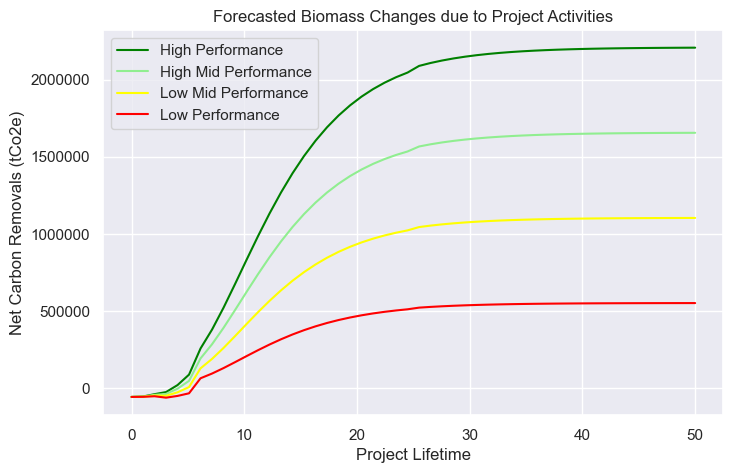

```python
plt.figure(figsize=(8,5))
plt.plot(x1, projectSums.iloc[:,1], label='High Performance', color = 'green')
plt.plot(x1, projectSums.iloc[:,2], label='High Mid Performance', color = 'lightgreen')
plt.plot(x1, projectSums.iloc[:,3], label='Low Mid Performance', color = 'yellow')
plt.plot(x1, projectSums.iloc[:,4], label='Low Performance', color = 'red')
plt.title('Forecasted Biomass Changes due to Project Activities')
plt.xlabel('Project Lifetime')
plt.ylabel('Net Carbon Removals (tCo2e)')
plt.ticklabel_format(style='plain', axis='y')
plt.legend()
plt.savefig('./imgsPhil/biomassTotal.png', facecolor='white')
plt.show()
```

#### VCU's Per Year

With the Chapman-Richards curve, RRG is estimating that planted stands will be fast growing and reach maturity around year 30. RRG and PEF will conduct future field inventories to validate and update current assumptions.

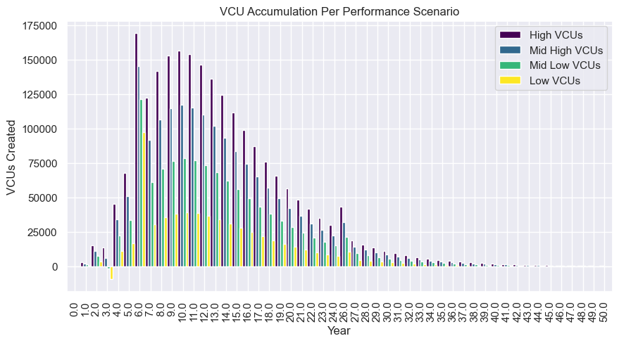

```python
vcu = projectSums.copy()
vcu['High VCUs'] = vcu.iloc[:,1].diff()
vcu['Mid High VCUs'] = vcu.iloc[:,2].diff()
vcu['Mid Low VCUs'] = vcu.iloc[:,3].diff()
vcu['Low VCUs'] = vcu.iloc[:,4].diff()
vcuDF = vcu.iloc[:,[0,-4,-3,-2,-1]]
vcuDF.iloc[:,0] = vcuDF.iloc[:,0].round()
vcuDF.head()
# Set index to Year
vcuDF.set_index('Year', inplace=True)
vcuDF.plot(kind='bar', stacked=False, figsize=(10,5), colormap='viridis', width=1.0)
plt.title('VCU Accumulation Per Performance Scenario')
plt.xlabel('Year')
plt.ylabel('VCUs Created')
plt.show()
```

```python
# test .diff() methodology to make sure diff sums = gross total
test = vcu.copy()
test.loc[0, 'High VCUs'] = projectSums.iloc[0, 1]
# Now cumulative sum
test['High VCUs CumSum'] = test['High VCUs'].cumsum()
test.loc[0, 'Mid High VCUs'] = projectSums.iloc[0, 2]
test['Mid High VCUs CumSum'] = test['Mid High VCUs'].cumsum()
test.loc[0, 'Mid Low VCUs'] = projectSums.iloc[0, 3]
test['Mid Low VCUs CumSum'] = test['Mid Low VCUs'].cumsum()
test.loc[0, 'Low VCUs'] = projectSums.iloc[0, 4]
test['Low VCUs CumSum'] = test['Low VCUs'].cumsum()
test.tail()
```

|  | Year | Net Co2e Removals High | Net Co2e Removals Mid High | Net Co2e Removals Mid Low | Net Co2e Removals Low | High VCUs | Mid High VCUs | Mid Low VCUs | Low VCUs | High VCUs CumSum | Mid High VCUs CumSum | Mid Low VCUs CumSum | Low VCUs CumSum |
| --- | --- | --- | --- | --- | --- | --- | --- | --- | --- | --- | --- | --- | --- |
| 45 | 46.0 | 2.204770e+06 | 1.653578e+06 | 1.102385e+06 | 551192.528251 | 705.828745 | 529.371559 | 352.914372 | 176.457186 | 2.204770e+06 | 1.653578e+06 | 1.102385e+06 | 551192.528251 |
| 46 | 47.0 | 2.205363e+06 | 1.654022e+06 | 1.102681e+06 | 551340.702750 | 592.697995 | 444.523496 | 296.348997 | 148.174499 | 2.205363e+06 | 1.654022e+06 | 1.102681e+06 | 551340.702750 |
| 47 | 48.0 | 2.205861e+06 | 1.654395e+06 | 1.102930e+06 | 551465.125620 | 497.691482 | 373.268612 | 248.845741 | 124.422871 | 2.205861e+06 | 1.654395e+06 | 1.102930e+06 | 551465.125620 |
| 48 | 49.0 | 2.206278e+06 | 1.654709e+06 | 1.103139e+06 | 551569.602883 | 417.909052 | 313.431789 | 208.954526 | 104.477263 | 2.206278e+06 | 1.654709e+06 | 1.103139e+06 | 551569.602883 |
| 49 | 50.0 | 2.206629e+06 | 1.654972e+06 | 1.103315e+06 | 551657.331234 | 350.913402 | 263.185051 | 175.456701 | 87.728350 | 2.206629e+06 | 1.654972e+06 | 1.103315e+06 | 551657.331234 |

## Remote Sensing Performance Benchmark

### Modeling of SI at Biomass

RRG has compared a range of stocking indices (SI) to monitor biomass accumulation. Below RRG compares a simple and complex biomass model.

#### Predicting Biomass from SAR HV

[SAR backscatter](https://developers.google.com/earth-engine/datasets/catalog/JAXA_ALOS_PALSAR_YEARLY_SAR) images are representations of the microwave portion of the electromagnetic spectrum. SAR data is commonly used for [detecting forest changes](https://earthdata.nasa.gov/s3fs-public/2025-04/SARHB_CH3_Content.pdf) and is less suceptible to seasonal variations. The following equation sums the model: $$ \text{Biomass} = f(\text{SAR HV}) $$ $$ \text{where Biomass = WCMC Aboveground and Belowground Biomass} $$

**Model Design**  
It's important to note that HV (db) index values are negative. Because of this, not all parametric models will work. Below we compare linear, polynomial, support vector and gradient boosted regression models.

```python
def SI_model(data):
    df = data.copy()
    x = df.iloc[:, 0]
    y = df.iloc[:, 1]
    xName = df.columns[0]
    yName = df.columns[1]
    # PARAMETRIC MODELING
    #linear modeling/polynomial
    results = smf.wls(f'{yName} ~ {xName}', data=df).fit()
    poly2 = smf.wls(f'{yName} ~ {xName} + I({xName}**2)', data=df).fit()
    poly3 = smf.wls(f'{yName} ~ {xName} + I({xName}**2) + I({xName}**3)', data=df).fit()
    # QUICK LOOK TO COMPARE MODEL OUTCOMES
    # Mean Percentage Error
    def mean_percentage_error(y_true, y_pred):
        y_true, y_pred = np.array(y_true), np.array(y_pred)
        nonzero_mask = y_true != 0
        if not np.any(nonzero_mask):
        # All y_true are zero, can't compute MPE
            return np.nan
        mpe = np.mean((y_true[nonzero_mask] - y_pred[nonzero_mask]) / y_true[nonzero_mask]) * 100
        return mpe
    def evaluate_model(name, y_true, y_pred, formula):
        return {
        'Model': name,
        'Formula': formula,
        'R²': r2_score(y_true, y_pred),
        'RMSE': np.sqrt(mean_squared_error(y_true, y_pred)),
        'MPE': mean_percentage_error(y_true, y_pred)
    }
    results_list = []
    y_pred_linear = results.predict(df)
    formula_linear = f"{yName} = {results.params['Intercept']:.3f} + {results.params[xName]:.3f} * {xName}"
    results_list.append(evaluate_model('Linear', df[yName], y_pred_linear, formula_linear))
    y_pred_poly2 = poly2.predict(df)
    formula_poly2 = (f"{yName} = {poly2.params['Intercept']:.3f} + "
                 f"{poly2.params[xName]:.3f} * {xName} + "
                 f"{poly2.params[f'I({xName} ** 2)']:.3f} * {xName}²")
    results_list.append(evaluate_model('Polynomial (2nd)', df[yName], y_pred_poly2, formula_poly2))
    y_pred_poly3 = poly3.predict(df)
    formula_poly3 = (f"{yName} = {poly3.params['Intercept']:.3f} + "
                 f"{poly3.params[xName]:.3f} * {xName} + "
                 f"{poly3.params[f'I({xName} ** 2)']:.3f} * {xName}² + "
                 f"{poly3.params[f'I({xName} ** 3)']:.3f} * {xName}³")
    results_list.append(evaluate_model('Polynomial (3rd)', df[yName], y_pred_poly3, formula_poly3))
    metrics_df = pd.DataFrame(results_list)
    metrics_df = metrics_df.sort_values(by='R²', ascending=False).reset_index(drop=True)
    #GRAPH RESULTS
    # Create x values
    x_vals = np.linspace(1.3 * df[xName].min(), 1.3 * df[xName].max(), 200)
    # Scatter plots of original data
    plt.figure(figsize=(12, 6))
    plt.scatter(df[xName], df[yName], label='GEE Data', color='lightblue', alpha=0.6, s=20)
    # Linear
    y_vals_linear = results.params['Intercept'] + results.params[xName] * x_vals
    plt.plot(x_vals, y_vals_linear, label='Linear', color='blue', linestyle='-')
    # Polynomial 2nd degree
    y_vals_poly2 = (poly2.params['Intercept']
                + poly2.params[xName] * x_vals
                + poly2.params[f'I({xName} ** 2)'] * x_vals**2)
    plt.plot(x_vals, y_vals_poly2, label='Polynomial (2nd)', color='green', linestyle='--')
    # Polynomial 3rd degree
    y_vals_poly3 = (
    poly3.params['Intercept']
    + poly3.params[xName] * x_vals
    + poly3.params[f'I({xName} ** 2)'] * x_vals**2
    + poly3.params[f'I({xName} ** 3)'] * x_vals**3
    )
    plt.plot(x_vals, y_vals_poly3, label='Polynomial (3rd)', color='darkgreen', linestyle=':')
    # Final plot formatting
    plt.ylim(-1, (1.2*df[yName].max()))
    plt.xlim((1.2* df[xName].min()), (1.2*df[xName].max()))
    plt.xlabel('HV Index Value (dB)')
    plt.ylabel('Biomass per ha (tC)')
    plt.title('Predicting Biomass per Hectare Given SAR HV Data')
    plt.legend()
    plt.show()
    return metrics_df
```

```python
def xgBoost(data):
    df = data.copy()
    x = df.iloc[:, 0].to_numpy().reshape(-1, 1)   # <-- convert to numpy array first
    y = df.iloc[:, 1].to_numpy()
    xName = df.columns[0]
    yName = df.columns[1]

    # Split data into train/test (80% train, 20% test)
    X_train, X_test, y_train, y_test = train_test_split(
        x, y, test_size=0.2, random_state=42)
    # Create XGBoost regressor
    model = xgb.XGBRegressor(
        objective='reg:squarederror',
        n_estimators=1000,
        max_depth=10,
        learning_rate=0.001,
        random_state=42
    )

    # Train model
    model.fit(X_train, y_train)

    # Predict on test set
    y_pred = model.predict(X_test)

    # Evaluate
    r2 = r2_score(y_test, y_pred)
    rmse = mean_squared_error(y_test, y_pred)
    print(f'R²: {r2:.3f}')
    print(f'RMSE: {rmse:.3f}')
    plt.figure(figsize=(8,6))
    plt.scatter(y_test, y_pred, alpha=0.5, edgecolors='k')
    plt.plot([y_test.min(), y_test.max()], [y_test.min(), y_test.max()], 'r--')
    plt.xlabel('Actual Biomass')
    plt.ylabel('Predicted Biomass')
    plt.title('XGBoost Predicted vs Actual Biomass')
    plt.grid(True)
    plt.show()
```

```python
def svr(data):
    df = data.copy()
    x = df.iloc[:, 0].to_numpy().reshape(-1, 1)   # <-- convert to numpy array first
    y = df.iloc[:, 1].to_numpy()
    xName = df.columns[0]
    yName = df.columns[1]

    # Split data into train/test (80% train, 20% test)
    X_train, X_test, y_train, y_test = train_test_split(
        x, y, test_size=0.2, random_state=42)

    model = SVR(kernel='rbf', C=10000, gamma='scale', epsilon=1)

    # Train model
    model.fit(X_train, y_train)

    # Predict on test set
    y_pred = model.predict(X_test)

    # Evaluate
    r2 = r2_score(y_test, y_pred)
    rmse = mean_squared_error(y_test, y_pred)
    print(f'R²: {r2:.3f}')
    print(f'RMSE: {rmse:.3f}')
    plt.figure(figsize=(8,6))
    plt.scatter(y_test, y_pred, alpha=0.5, edgecolors='k')
    plt.plot([y_test.min(), y_test.max()], [y_test.min(), y_test.max()], 'r--')
    plt.xlabel('Actual Biomass')
    plt.ylabel('Predicted Biomass')
    plt.title('XGBoost Predicted vs Actual Biomass')
    plt.grid(True)
    plt.show()
```

**Data Collection**

```python
# FOR SAR DATA COLLECTION
year = 2010
palsar = ee.ImageCollection('JAXA/ALOS/PALSAR/YEARLY/SAR_EPOCH')\
  .filterDate(f'{year}-01-01', f'{year}-04-01').filterBounds(projectsites)
def applyQualityMask(image):
    # Assuming 'MSK' is the data quality mask band
    msk = image.select('qa')
    # Mask out pixels with value 50 (commonly water/invalid in ALOS PALSAR)
    mask = msk.neq(50)
    masked_image = image.updateMask(mask)
    return masked_image
def convertToGammaNaught(image):
    # Convert DN to gamma naught (γ₀) in decibels
    gamma_naught = image.pow(2).log10().multiply(10).subtract(83)
    return gamma_naught
collection = (
    palsar
    .map(convertToGammaNaught)  # Convert DN to gamma naught
    .map(applyQualityMask)
)
palsarImage = collection.median().clip(SIGeom)
hvImage = palsarImage.select('HV') #Users can select
#HH or HV to compare. RRG compared and HV was shown to be the best index for Mindanao
hvVis = {
  'min': -30,
  'max': 0,
  'palette': ['red', 'yellow', 'green']
}
SARMap = geemap.Map(notebook_display=True)
SARMap.add_basemap('HYBRID')
SARMap.addLayer(hvImage, hvVis, 'HV 2020 (db)')
SARMap.addLayer(agbGEDI2020, agbVis, 'Agb GEDI 2020')
SARMap.addLayer(projectsites, psiteVis, 'Project Sites')
SARMap.centerObject(projectsites, 10)
SARMap.add_inspector()
```

[figure not shown]

**Dataset Cleaning and Quick Look**  
This raw dataset includes each sampled point, including the coordinates. Auditors can cross reference each sampled point in the mapping app of their choice.  
There are differing resolutions between AGB datasets (300m) and SAR HH datasets (25m). So, there are many HH measurements per AGB measurement. To smoothe this, RRG has taken the mean of all HH values at each AGB value.

```python
sar_df = pd.read_csv('./sheetsPhil/BiomassHVComparisonPhilSI_Sites4.csv')
sar_df.head(1)
```

|  | system:index | HV | carbon_tonnes_per_ha | .geo |
| --- | --- | --- | --- | --- |
| 0 | 0 | -9.958943 | 114.800003 | {"type":"Point","coordinates":[124.50262964384798,7.690992598541853]} |

```
Spearman Correlation: 0.592060762733015
```

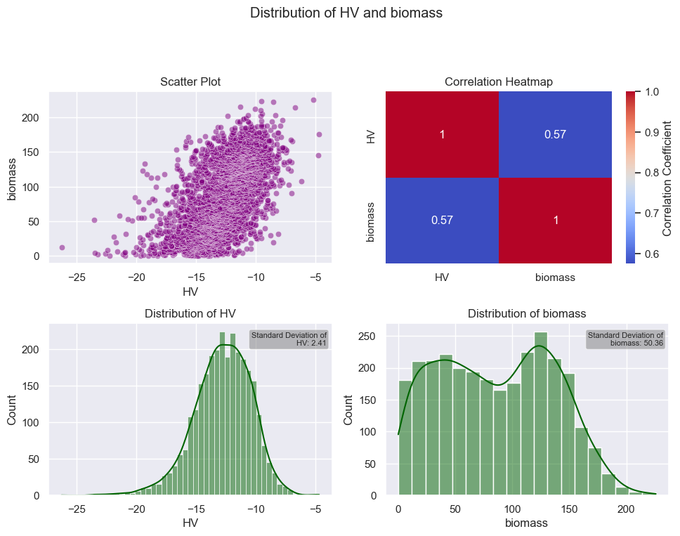

```
None
```

```python
rawSAR = sar_df.iloc[:, [1, 2]]
rawSAR.columns.values[1] = 'biomass'
rawSAR = rawSAR.round(2)
dfSAR = rawSAR.groupby('biomass')['HV'].mean().reset_index()
dfSAR = dfSAR.iloc[:, [1,0]]
print(ql(dfSAR))
```

```
R²: 0.284
RMSE: 1866.629
```

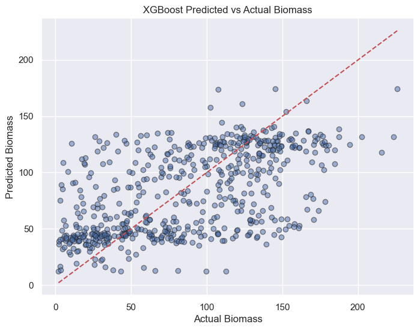

```python
svr(dfSAR)
```

```
R²: 0.282
RMSE: 1872.226
```

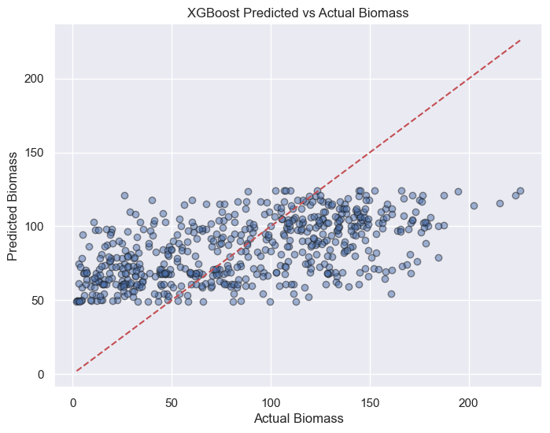

```python
xgBoost(dfSAR)
```

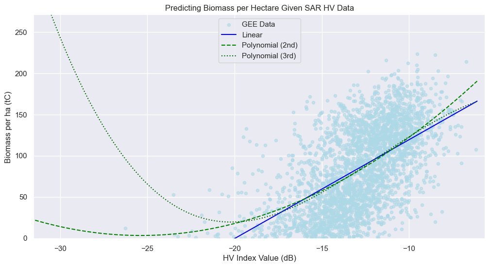

|  | Model | Formula | R² | RMSE | MPE |
| --- | --- | --- | --- | --- | --- |
| 0 | Polynomial (3rd) | biomass = 153.962 + -13.884 * HV + -2.364 * HV² + -0.067 * HV³ | 0.344282 | 40.769044 | -143.087619 |
| 1 | Polynomial (2nd) | biomass = 327.932 + 25.596 * HV + 0.504 * HV² | 0.339433 | 40.919530 | -144.526034 |
| 2 | Linear | biomass = 239.448 + 11.997 * HV | 0.330007 | 41.210450 | -134.593398 |

```python
metrics_df = SI_model(dfSAR)
metrics_df
```

**Model Selection**  
It's evident RRG's dataset is noisy and results in low R2 values. When comparing model results and curve shapes, RRG chose the 2nd Polynomial equation for export due to it's high end (150-200ha) biomass estimates. Moving into the future, RRG will refine these models.

```python
def biomass_HV(HV):
    biomass = 327.932 + 25.596 * HV + 0.504 * HV**2
    return(biomass)
```

**Data Collection**

```python
# FOR SAR DATA COLLECTION
year = 2010
palsar = ee.ImageCollection('JAXA/ALOS/PALSAR/YEARLY/SAR_EPOCH')\
  .filterDate(f'{year}-01-01', f'{year}-04-01').filterBounds(projectsites)
def applyQualityMask(image):
    # Assuming 'MSK' is the data quality mask band
    msk = image.select('qa')
    # Mask out pixels with value 50 (commonly water/invalid in ALOS PALSAR)
    mask = msk.neq(50)
    masked_image = image.updateMask(mask)
    return masked_image
def convertToGammaNaught(image):
    # Convert DN to gamma naught (γ₀) in decibels
    gamma_naught = image.pow(2).log10().multiply(10).subtract(83)
    return gamma_naught
collection = (
    palsar
    .map(convertToGammaNaught)  # Convert DN to gamma naught
    .map(applyQualityMask)
)
palsarImage = collection.median().clip(SIGeom)
hvImage = palsarImage.select('HV') #Users can select
#HH or HV to compare. RRG compared and HV was shown to be the best index for Mindanao
hvVis = {
  'min': -30,
  'max': 0,
  'palette': ['red', 'yellow', 'green']
}
SARMap = geemap.Map(notebook_display=True)
SARMap.add_basemap('HYBRID')
SARMap.addLayer(hvImage, hvVis, 'HV 2020 (db)')
SARMap.addLayer(agbGEDI2020, agbVis, 'Agb GEDI 2020')
SARMap.addLayer(projectsites, psiteVis, 'Project Sites')
SARMap.centerObject(projectsites, 10)
SARMap.add_inspector()
```

### Baseline Biomass

RRG will utilize time series analysis to determine the baseline conditions of the project sites at three distinct time periods from t=-8, t=-3, and t=0. This corresponds to 2015, 2020 and 2023.

#### Using SAR Data

RRG utilized the Jaxa yearly mosaic going back to 2010 for the training models. However, this dataset does not provide data beyond 2020. Despite this, Jaxa provides multiple datasets with more up to date data. RRG will utilize [this dataset](https://developers.google.com/earth-engine/datasets/catalog/JAXA_ALOS_PALSAR_YEARLY_SAR_EPOCH#bands) for baseline biomass analysis.

```python
year = (2015, 2020, 2023)
palsar_images = []
for time in year:
    palsar = ee.ImageCollection('JAXA/ALOS/PALSAR/YEARLY/SAR_EPOCH')\
        .filterDate(f'{time}-01-01', f'{time + 1}-01-01')\
        .filterBounds(projectsites)
    print(f"{time}: {palsar.size().getInfo()} images")
    collection = (
        palsar
        .map(convertToGammaNaught)  # Your preprocessing steps
        .map(applyQualityMask)
    )
    palsarImage = collection.first().clip(projectsites)
    hvImage = palsarImage.select('HV') #Users can select HH or HV
    # Append to list
    palsar_images.append(hvImage)
```

```
2015: 1 images
2020: 1 images
2023: 1 images
```

```python
SARMap = geemap.Map(notebook_display=True)
SARMap.add_basemap('HYBRID')
SARMap.addLayer(palsar_images[0], hvVis, 'HV (db) 2015')
SARMap.addLayer(palsar_images[1], hvVis, 'HV (db) 2020')
SARMap.addLayer(palsar_images[2], hvVis, 'HV (db) 2023')
SARMap.addLayer(projectsites, psiteVis, 'Project Sites')
SARMap.centerObject(projectsites, 10)
SARMap.add_inspector()
```

[figure not shown]

```python
# export
palsar_images_named = [
    palsar_images[0].rename(['HH_2015']),
    palsar_images[1].rename(['HH_2020']),
    palsar_images[2].rename(['HH_2023'])
]
stacked = ee.Image.cat(palsar_images_named)
sampled = stacked.sampleRegions(
    collection=projectsites.select(['id']),  # keep only 'Sitio' column
    scale=25,
    geometries=True
)
task = ee.batch.Export.table.toDrive(
    collection=sampled,
    folder='gee_exports',
    fileNamePrefix='HVBaselineProjectSites3',
    fileFormat='CSV'
)
task.start()
```

**Load Dataset**

```python
SARts = pd.read_csv('./sheetsPhil/HVBaselineProjectSites3.csv')
SARts = SARts.drop(SARts.columns[0], axis=1)
SARts.head(1) #includes coordinates for auditing, id corresponding to each project plot
```

|  | HH_2015 | HH_2020 | HH_2023 | id | .geo |
| --- | --- | --- | --- | --- | --- |
| 0 | -14.627346 | -12.263783 | -13.788056 | 1 | {"geodesic":false,"type":"Point","coordinates":[125.30356595966032,7.213020118157942]} |

**Biomass Conversion and Scaling**  
The SAR training models are meant to predict biomass at the hectare level. However, each SAR pixel is only 25m x 25 or 0.0625 hectares. Therefore, RRG scaled each biomass prediction by 0.0625 to get the biomass per pixel

```python
SARts['Biomass_2015'] = (biomass_HV(SARts['HH_2015']) * 0.0625)
SARts['Biomass_2020'] = (biomass_HV(SARts['HH_2020']) * 0.0625)
SARts['Biomass_2023'] = (biomass_HV(SARts['HH_2023']) * 0.0625)
tsDF = SARts.iloc[:,[-1, -2, -3, 3]]
tsDF.head(1)
```

|  | Biomass_2023 | Biomass_2020 | Biomass_2015 | id |
| --- | --- | --- | --- | --- |
| 0 | 4.426788 | 5.614375 | 3.835369 | 1 |

#### Site Totals

```
   id  Biomass_2023  Biomass_2020  Biomass_2015
0   1      66618.99      67064.85      67103.53
1   4      44691.40      48221.95      46240.28
2   3      30413.47      32947.03      32015.33
3   5      25890.14      26512.93      25150.01
4   6      15528.33      16259.80      15990.62
5   7      11630.83      12472.39      11637.10
6   2       6889.89       7099.40       7193.51
```

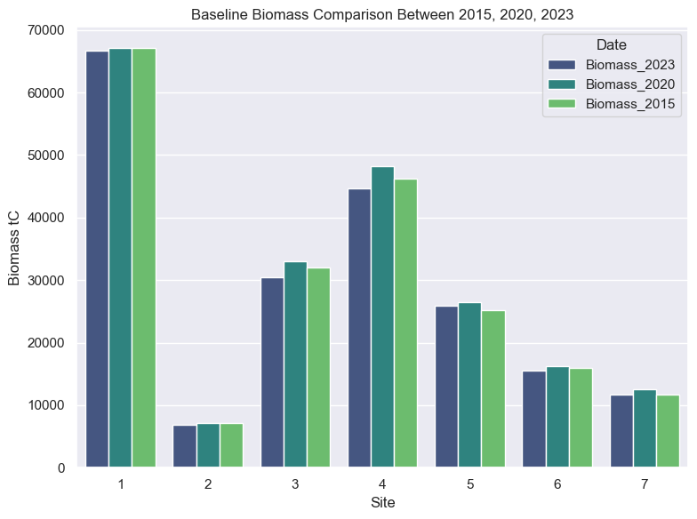

```python
totals = tsDF.groupby('id')[['Biomass_2023', 'Biomass_2020', 'Biomass_2015']].sum().sort_values(by='Biomass_2023', ascending=False)
t = totals.reset_index().round(decimals=2)
print(t)
# Melt to long-form for Seaborn
df_melted = pd.melt(t,
                    id_vars='id',
                    value_vars=['Biomass_2023', 'Biomass_2020', 'Biomass_2015'],
                    var_name='Date',
                    value_name='Biomass')
# Plot
plt.figure(figsize=(8, 6))
sns.barplot(data=df_melted, x='id', y='Biomass', hue='Date', palette="viridis")
plt.xlabel('Site')
plt.ylabel('Biomass tC')
plt.title('Baseline Biomass Comparison Between 2015, 2020, 2023')
plt.tight_layout()
sns.set_theme()
plt.show()
```

#### Average Biomass Per Hectare Per Site

```python
pSites = pd.read_csv('./sheetsPhil/projectsitesmeta.csv')
pSites.iloc[:, -2] = pSites.iloc[:, -2].round(2)
pSites = pSites.iloc[:, [0,-2]]
mergepSite = pd.merge(t, pSites, on='id')
mergepSite['Avg Biomass/ha 2023'] = mergepSite.iloc[:,1] / mergepSite.iloc[:,4]
mergepSite['Avg Biomass/ha 2020'] = mergepSite.iloc[:,2] / mergepSite.iloc[:,4]
mergepSite['Avg Biomass/ha 2015'] = mergepSite.iloc[:,3] / mergepSite.iloc[:,4]
mergepSite.sort_values(by='Avg Biomass/ha 2023')
```

|  | id | Biomass_2023 | Biomass_2020 | Biomass_2015 | Area | Avg Biomass/ha 2023 | Avg Biomass/ha 2020 | Avg Biomass/ha 2015 |
| --- | --- | --- | --- | --- | --- | --- | --- | --- |
| 6 | 2 | 6889.89 | 7099.40 | 7193.51 | 76.61 | 89.934604 | 92.669364 | 93.897794 |
| 3 | 5 | 25890.14 | 26512.93 | 25150.01 | 277.64 | 93.250756 | 95.493913 | 90.584966 |
| 0 | 1 | 66618.99 | 67064.85 | 67103.53 | 713.49 | 93.370601 | 93.995501 | 94.049713 |
| 2 | 3 | 30413.47 | 32947.03 | 32015.33 | 313.76 | 96.932273 | 105.007107 | 102.037640 |
| 4 | 6 | 15528.33 | 16259.80 | 15990.62 | 149.32 | 103.993638 | 108.892312 | 107.089606 |
| 1 | 4 | 44691.40 | 48221.95 | 46240.28 | 412.42 | 108.363804 | 116.924373 | 112.119393 |
| 5 | 7 | 11630.83 | 12472.39 | 11637.10 | 105.96 | 109.766233 | 117.708475 | 109.825406 |

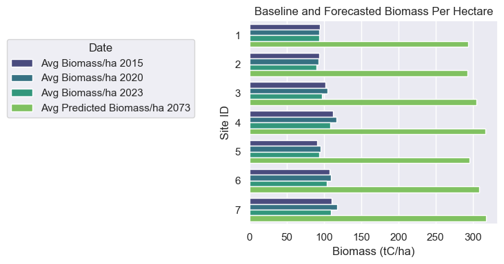

```python
#vizualize change in tC/ha
change = mergepSite.iloc[:, [0, -1, -2, -3]].copy()
change['Avg Predicted Biomass/ha 2073'] = change.iloc[:,-2] + 200
change.head()
# Melt DataFrame: id on y-axis, biomass values on x-axis
df_melted = pd.melt(
    change,
    id_vars='id',
    value_vars=change.columns[1:],  # skip 'id', melt other columns
    var_name='Date',
    value_name='Biomass'
)

# Plot
plt.figure(figsize=(8, 4))
ax = sns.barplot(
    data=df_melted,
    x='Biomass',   # biomass on x-axis
    y='id',        # site ID on y-axis
    hue='Date',
    palette="viridis",
    orient='h'
)
sns.move_legend(ax, "lower right" , bbox_to_anchor=(-.2, .5))
plt.xlabel('Biomass (tC/ha)')
plt.ylabel('Site ID')
plt.title('Baseline and Forecasted Biomass Per Hectare')
plt.tight_layout()
plt.show()
```

#### Model Performance Discussion

RRG understands the importance of accurate remote sensing and field monitoring systems to quantify biomass changes throughout the project lifetime. This document will serve as a living library and will be updated as RRG makes upgrades.